# Addressing Gender Gap at ISED

The Sloths

February 6, 2022

# Addressing Gender Gap at ISED

## Gap between female/gender diverse and male individuals

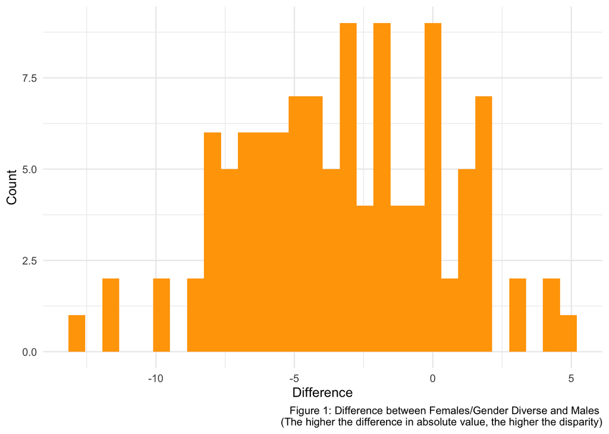

```
##
##  One Sample t-test
##
## data:  gender_diff$diff
## t = -9.5733, df = 112, p-value < 2.2e-16
## alternative hypothesis: true mean is less than 0
## 95 percent confidence interval:
##       -Inf -2.728399
## sample estimates:
## mean of x
## -3.300147
```

Since we have noticed some plausible differences in Figure 1, we can conduct a t-test to figure out whether the difference of scores between the two groups are equal to 0 or less than 0. As a result, we have strong evidence against the hypothesis that the scores between males and females are equal to 0. Hence, we conclude that the difference in scores are less than zero for males and females/gender diverse employees.

Now, let us investigate some of the survey questions to see what might be the underlying causes of such difference in scores.

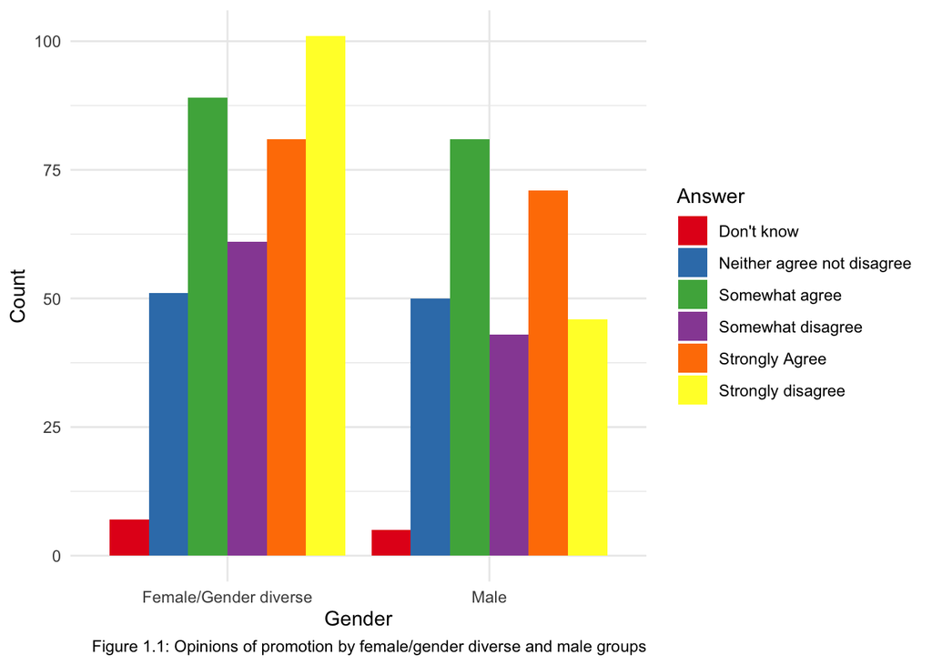

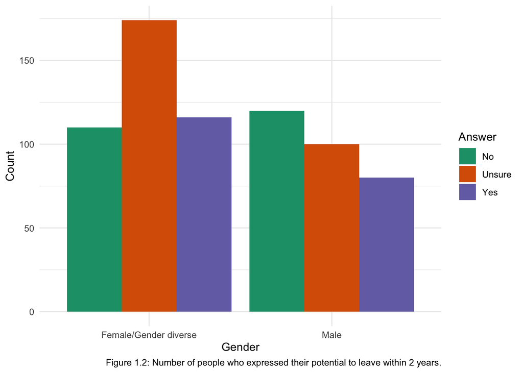

Meanwhile, we see in Figure 1.2 that several people in the female/gender diverse group strongly expressed their intent to leave ISED within the next 2 years in comparison to the proportion in male individuals. Also, a lot of female/gender diverse individuals were unsure of leaving within the 2 years, which could imply that we need to further investigate what might be the cause of it.

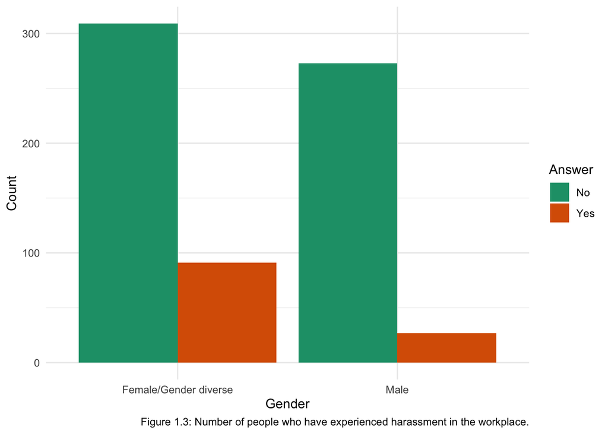

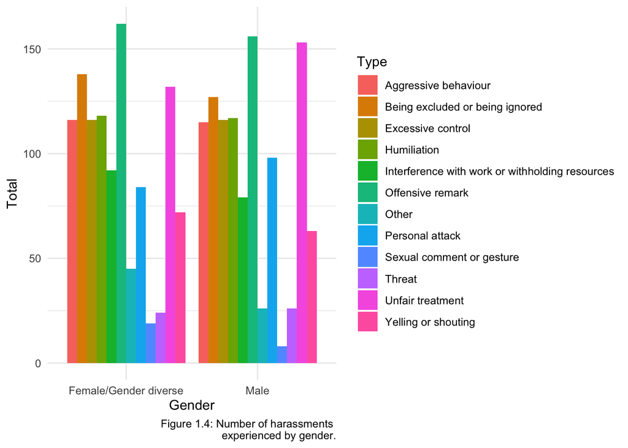

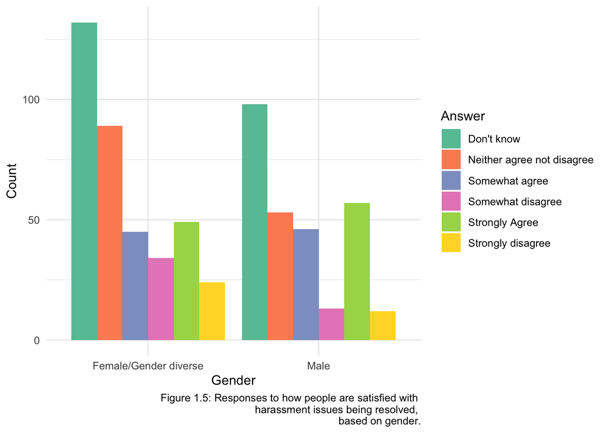

Finally, Figure 1.5 shows how people are satisfied with harassment issues being resolved. In general, many people in the female/gender diverse category were neutral. Moreover, there were more female/gender diverse individuals who somewhat disagreed with the resolutions compared to male workers. A lot of male individuals responded “Don’t know” followed by “Strongly agree” as the second most frequent response. Regarding the fact that many responses were neutral, we can infer that people are not fully satisfied with the harassment issues being resolved.

### Conclusion

Based on the survey responses and the dataset that we were given, it is difficult to determine the number of female/gender diverse employees and male employees at ISED. We can only tell that there were more female/gender diverse individuals who responded to the survey. If a lot of female/gender diverse individuals decided to answer questions more than males in order to raise their voices on inequity in the workplace, this could mean that we might need to work more on promoting gender equity / equality in the workplace.

We could possibly give a few suggestions to ISED using the results above. First, they can foster gender equity / equality starting with the recruitment process. Hiring more EE (Employment equity) groups will lead to more equal outcomes. During the recruitment process, ISED should make sure recruitment managers go through adequate training sessions to reduce internal bias towards job candidates regarding their gender. They can also diversify hiring managers. For instance, they can have an equal/similar number of men, women, gender diverse hiring managers. Finally, when it comes to harassment issues, the company should hold people accountable such as the offender of harassment and the manager. It is essential that all individuals in the workplace go through adequate hours of training to reduce harassment issues.